# Teaching with Real Data Notes

Thomas J. Pfaff

Return to [Teaching with Real Data](https://thomas-pfaff.github.io/TeachingRealData.html)

## Info

**Source:** Trends in CO2, CH4, N2O, SF6 from NOAA Global Monitoring Laboratory

**Authors:** Dr. Xin Lan, NOAA/GML (gml.noaa.gov/ccgg/trends/) and Dr. Ralph Keeling, Scripps Institution of Oceanography (scrippsco2.ucsd.edu/).

**Date:** Updated daily

**Link:** https://gml.noaa.gov/ccgg/trends/data.html

##### Notes

The data set includes the yearly average measurement of CO2 at the Mauna Loa site in ppm from 1959 to 2025. The data is a good example of residuals showing curvature in linear regression. A quadratic fit is a useful function in math classes and an example calculus project is below.

##### Uses

- **Regression:** The residuals from linear regression will show clear curvature indicating the a line isn’t the best option. Quadratic regression works well.
- **Calculus Project:** See example below.

##### Example Calculus Project

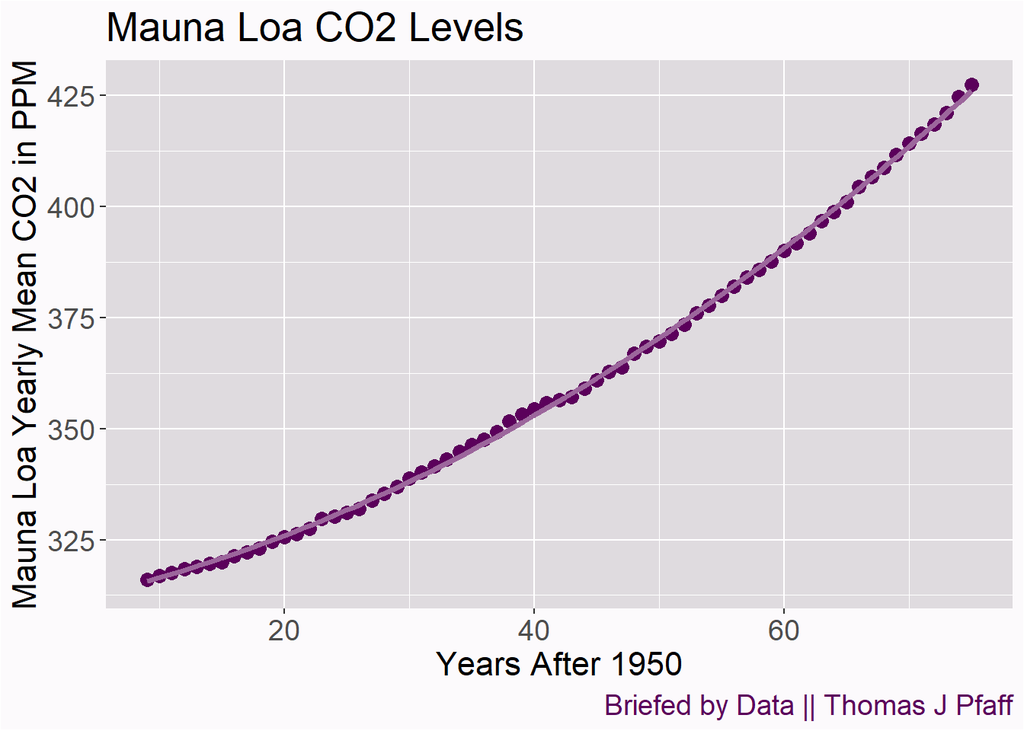

```
## y= 309.701627763388 + 0.543516593342905x + 0.013433919594167x^2
```

```
## Last Year in Data is 2025
```

Answer the following questions using the fitted curve, input years after 1950 and output ppm, above and represented in the Figure.

1. Find a model with output Average CO2 in PPM and input years (or years after 1950). [Either delete this question or the figure, in which case provide the data.]
2. According to the model what will CO2 levels be in 2050?
3. What is the rate of change of CO2 in (use the last year of the data set) and what is the percentage rate of change?
4. Assuming that CO2 levels continue to grow constantly at the (last year in data) rates, what will the CO2 levels reach in 2050?
5. Atmospheric CO2 levels of 450ppm yield a likely chance that global average temperature increases will be at least 20 Celsius. According to the model, in what year do we reach a CO2 level of 450ppm? If we assume CO2 levels continue to grow constantly at the (last year in data) rates, in what year do we reach a CO2 level of 450ppm?
6. Fill in the blank: In order to avoid reaching 450ppm of atmospheric CO2 the trend in the data would have to become (???Calculus Term???).
7. Provide a (general or real world related) question that you would like answered based on your work here. This should not be something that you could answer yourself with a little work.
8. Summarize your work on questions 1-5 in a short paragraph as if it were a news article.